# Analiza danych szeregów czasowych dotyczących sprzedaży

Adam Bartosiak

2026-06-07

**1. Wprowadzenie i Wczytanie Danych**

Raport ten przedstawia analizę danych sprzedażowych firmy detalicznej, wykorzystując autorski pakiet R do analizy. Dane obejmują historię sprzedaży, informacje o sklepach oraz dni świąteczne.

W pierwszej kolejności wczytujemy surowe dane i przeprowadzamy ich walidację (m.in. sprawdzanie braków, duplikatów i niespójności w datach kalendarzowych). Następnie czyścimy dane, agregując je do poziomu miesięcznego, aby wyeliminować szum informacyjny wynikający z dziennej zmienności i cykli tygodniowych.

```r
df_raw <- load_sales_data("train.csv", "stores.csv", "holidays_events.csv") # Wczytanie danych
invisible(validate_sales_ts(df_raw))
```

```
## [[1]]
## [1] "Wykryto luki w datach."
```

```r
df_raw <- df_raw %>% filter(as.Date(date) < as.Date("2017-08-01")) # usunięcie niepełnego miesiąca
df_clean <- clean_sales_ts(df_raw, agg_level = "month") # agregacja miesięczna
```

**2. Podsumowanie Biznesowe**

Poniżej znajduje się skrócone zestawienie wyników dla kadry menedżerskiej, wskazujące najlepiej i najgorzej radzące sobie sklepy oraz wiodącą kategorię produktową.

```r
summary <- create_management_summary(df_clean)

# Wyświetlenie wyników

kable(data.frame(
  "Metryka" = c("Najlepszy Sklep (ID)", "Najgorszy Sklep (ID)", "Najlepsza Kategoria"),
  "Wartość" = c(summary$Best_Store, summary$Worst_Store, summary$Top_Category)
))
```

| Metryka | Wartość |
| --- | --- |
| Najlepszy Sklep (ID) | 44 |
| Najgorszy Sklep (ID) | 52 |
| Najlepsza Kategoria | GROCERY I |

**Wniosek:** Zasoby marketingowe i zaopatrzeniowe powinny być w pierwszej kolejności kierowane do wiodącej kategorii oraz najlepszych sklepów z jednoczesnym przeprowadzeniem audytów w najsłabszych lokalizacjach.

**3. Analiza trendów sprzedażowych i metryki**

Obliczamy zaawansowane metryki biznesowe (w tym średnią odległość między szczytami sprzedaży) i wizualizujemy długoterminowe trendy.

```r
# Obliczanie metryk
metrics <- compute_sales_metrics(df_clean)

# Prezentacja przykładowych metryk z ostatnich miesięcy
tail(metrics %>% select(date, total_sales, avg_sales, avg_peak_distance_days), 5) %>% kable()
```

| date | total_sales | avg_sales | avg_peak_distance_days |
| --- | --- | --- | --- |
| 2017-03-01 | 26704018 | 14985.42 | 102.6 |
| 2017-04-01 | 26636198 | 14947.36 | 102.6 |
| 2017-05-01 | 26911847 | 15102.05 | 102.6 |
| 2017-06-01 | 27868044 | 15638.63 | 102.6 |
| 2017-07-01 | 27936621 | 15677.12 | 102.6 |

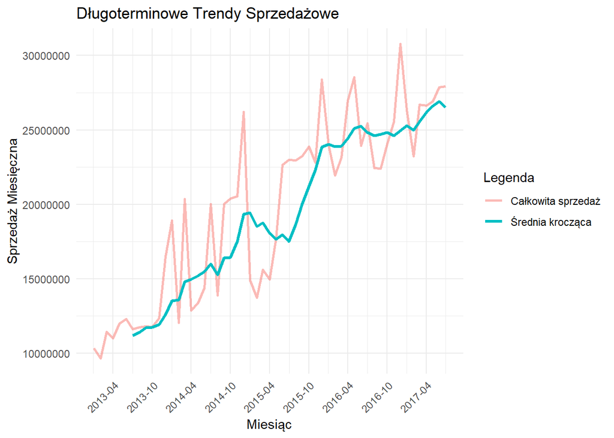

```r
# Wizualizacja trendu
plot_sales_trends(metrics)
```

**Wniosek:** Widoczna na wykresie wygładzona krzywa miesięczna uwydatnia stabilny rozwój sieci oraz cykliczne wzrosty sprzedaży, szczególnie zauważalne w grudniu (okres świąteczny).

**4. Analiza skuteczności promocji**

Weryfikujemy hipotezę, czy zwiększony udział promocji w danym miesiącu realnie przekłada się na wyższy wolumen sprzedaży.

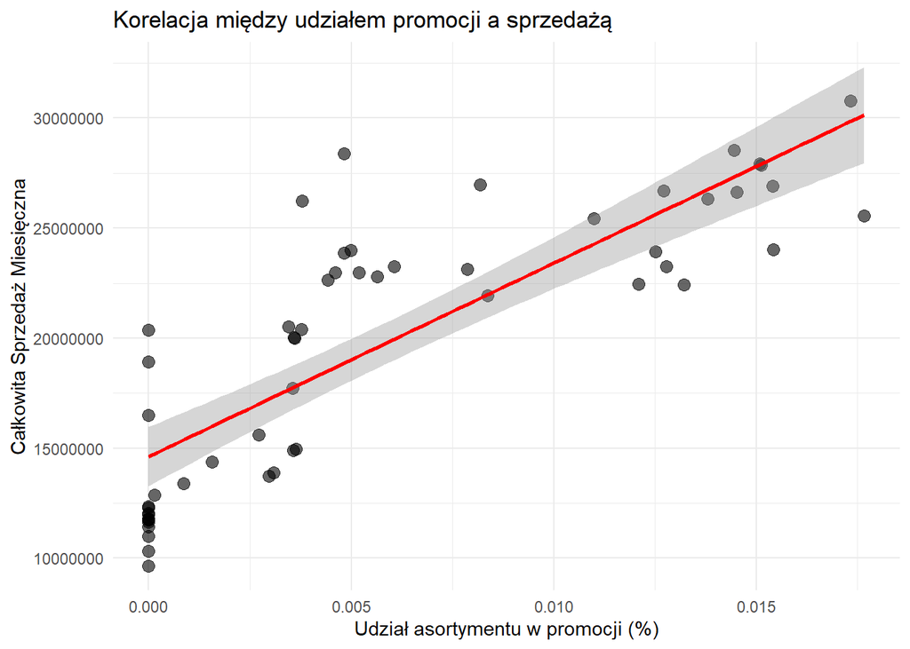

```r
ggplot(metrics, aes(x = promo_share, y = total_sales)) +
  geom_point(alpha = 0.6, color = "black", size = 3) +
  geom_smooth(method = "lm", color = "red", se = TRUE) +
  labs(
    title = "Korelacja między udziałem promocji a sprzedażą",
    x = "Udział asortymentu w promocji (%)",
    y = "Całkowita Sprzedaż Miesięczna"
  ) +
  theme_minimal()
```

**5. Bezpośrednie porównanie kategorii produktowych**

Porównujemy dynamikę sprzedaży dwóch historycznie najsilniejszych rodzin produktowych na przestrzeni analizowanych okresów.

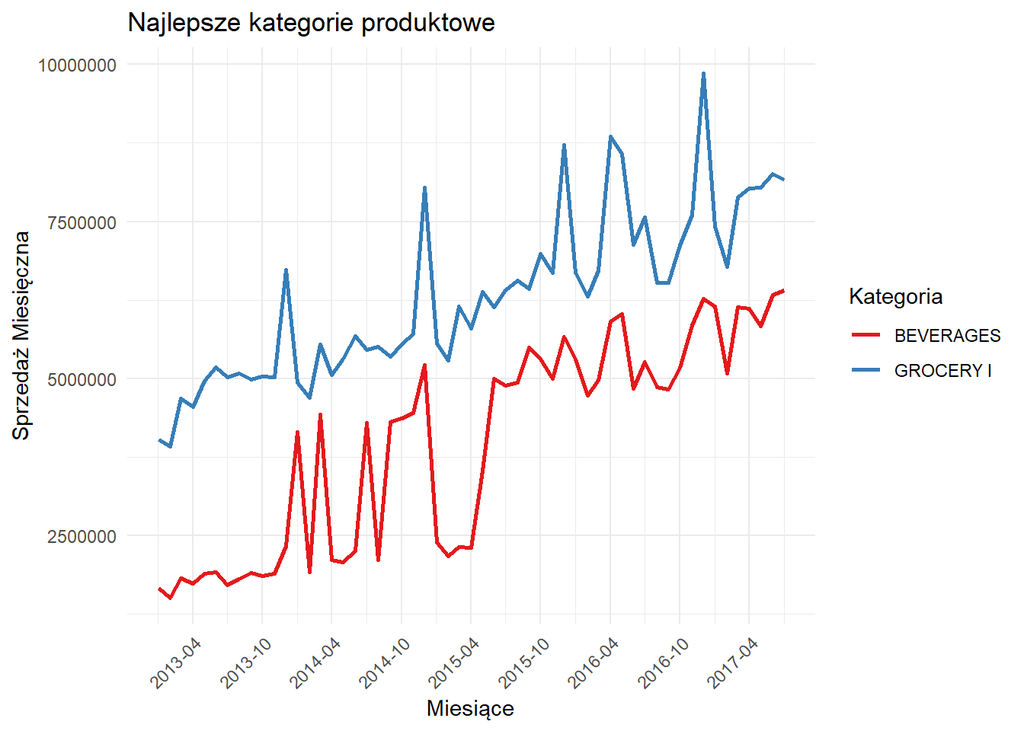

```r
# Wyodrębnienie dwóch najlepszych kategorii
top_2_cats <- df_clean %>%
  group_by(family) %>%
  summarise(sum_sales = sum(sales, na.rm = TRUE)) %>%
  arrange(desc(sum_sales)) %>%
  head(2) %>%
  pull(family)

# Filtrowanie i agregacja dla wykresu
df_top_cats <- df_clean %>%
  filter(family %in% top_2_cats) %>%
  group_by(date, family) %>%
  summarise(sales = sum(sales, na.rm = TRUE), .groups = "drop")

ggplot(df_top_cats, aes(x = date, y = sales, color = family)) +
  geom_line(size = 1) +
  scale_x_date(date_breaks = "6 months", date_labels = "%Y-%m") +
  labs(
    title = "Najlepsze kategorie produktowe",
    x = "Miesiące",
    y = "Sprzedaż Miesięczna",
    color = "Kategoria"
  ) +
  theme_minimal() +
  scale_color_brewer(palette = "Set1") +
  theme(axis.text.x = element_text(angle = 45, hjust = 1))
```

**Wniosek:** Zestawienie pozwala ocenić, która z wiodących kategorii wykazuje stabilny wzrost w ujęciu wielomiesięcznym, a która charakteryzuje się wyższą podatnością na roczne wahania sezonowe.

**6. Analiza wybranej lokalizacji**

Wykorzystujemy funkcję wyższego rzędu sales_ts_logic(), aby wyizolować dane dla danej lokalizacji (poniżej przykład miasta Quito) i ocenić lokalne wzorce sprzedaży na tle całego kraju.

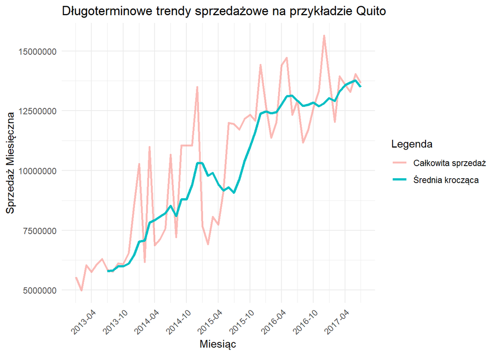

```r
# Analiza dla wybranego miasta
quito_analysis <- sales_ts_logic(df_clean, p_city = "Quito")

# Wyświetlenie dedykowanego wykresu
quito_analysis$plot + labs(
  title = "Długoterminowe trendy sprzedażowe na przykładzie Quito",
  y = "Sprzedaż Miesięczna"
)
```

**Wniosek:** Analiza regionalna dla kluczowego ośrodka miejskiego pozwala zweryfikować, czy lokalny rynek w stolicy rozwija się w tempie spójnym z resztą kraju. Wyłapanie lokalnych anomalii (np. spadków niewidocznych na wykresie ogólnokrajowym) jest kluczowe dla dostosowania lokalnej strategii cenowej.

**7. Prognozowanie przyszłej sprzedaży**

Wykorzystujemy dwa niezależne algorytmy do wyznaczenia predykcji na kolejne 12 miesięcy.

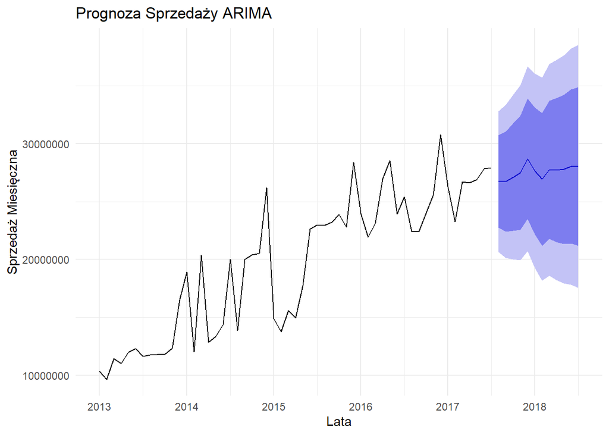

```r
library(forecast)

# Generowanie prognoz na 12 miesięcy
forecasts <- create_prognosis(df_clean, periods = 12)

# Wykres ARIMA
autoplot(forecasts$ARIMA) +
  labs(title = "Prognoza Sprzedaży ARIMA",
       y = "Sprzedaż Miesięczna", x = "Lata") +
  theme_minimal()
```

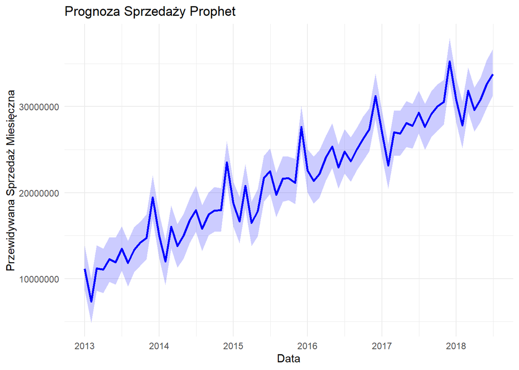

```r
# Wykres Prophet
ggplot(forecasts$Prophet, aes(x = as.Date(ds), y = yhat)) +
  geom_line(color = "blue", size = 1) +
  geom_ribbon(aes(ymin = yhat_lower, ymax = yhat_upper), alpha = 0.2, fill = "blue") +
  scale_x_date(date_breaks = "1 year", date_labels = "%Y") +
  labs(title = "Prognoza Sprzedaży Prophet",
       x = "Data", y = "Przewidywana Sprzedaż Miesięczna") +
  theme_minimal()
```